# Using hyperspectral remote sensing data to predict biodiversity

Showing some neat features of R!

Author

Affiliation

[Jesús N. Pinto-Ledezma](https://jesusnpl.github.io)

[Ecology, Evolution & Behavior, University of Minnesota Biodiversity Science - EBB 3534-5534](https://github.com/jesusNPL/BiodiversityScience)

Published

April 21, 2026

**Note**

In this lab we will explore some aspects of **hyperspectral** remote sensing obtained from the National Ecological Observatory Network ([NEON](https://data.neonscience.org)) with the goal of predicting biodiversity from the sky. Specifically, we will use hyperspectral remote sensing data from the **NEON** Airborne Observation Platform (**AOP**) (more information [here](https://www.neonscience.org/data-collection/airborne-remote-sensing) and [here](https://data.neonscience.org/data-products/DP3.30006.001)). As you will see, working with hyperspectral information/data is similar to work with any other information/data (e.g., species abundance, presence-absence) and consequently it can be used to calculate any metric of biodiversity. In this sense, **spectral diversity** can be considered as a dimension of biodiversity.

Note. Part of the text used in this tutorial was extracted from [here](https://www.neonscience.org/resources/learning-hub/tutorials/hsi-hdf5-r) with several modifications.

# 1 Set up your data and your working directory

Set up a working directory and store the data files in that directory. Tell R that this is the directory you will be using, and read in your data:

```r
setwd("..your working directory")
```

To do this laboratory you will need to install the following packages:

```r
# Package vector names
packages <- c("neonUtilities", "BiocManager", "plyr", "reshape2",
              "terra", "sf", "sp", "dismo")
```

**TipFunction install.packages()**

You can use the function **install.packages()** to install the packages.

If you don’t want to install the packages one by one, you can use the next command.

```r
# Install packages not yet installed
installed_packages <- packages %in% rownames(installed.packages())

if (any(installed_packages == FALSE)) {
  install.packages(packages[!installed_packages], dependencies = TRUE)
}
```

The package {rhdf5} is not available on CRAN, but it is located in “Bioconductor”.

When installing the package {**rhdf5**} R will ask you if you want to **“Update all/some/none? [a/s/n]:”** please in your console type **n**.

```r
if ( ! ("rhdf5" %in% installed.packages())) {BiocManager::install("rhdf5")}
```

Call or load all packages

```r
sapply(packages, require, character.only = TRUE)
```

```
Bioconductor version '3.21' is out-of-date; the current release version '3.22'
  is available with R version '4.5'; see https://bioconductor.org/install
```

```
terra 1.9.11
```

```
neonUtilities   BiocManager          plyr      reshape2         terra
         TRUE          TRUE          TRUE          TRUE          TRUE
           sf            sp         dismo
         TRUE          TRUE          TRUE
```

```r
library(rhdf5)
library(tidyverse)
```

Double-check your working directory.

**TipFunction getwd()**

You can use the function **getwd()** to get the current working directory.

# 2 Data preparation

```r
dir.create("data")
dir.create("data/NEON")
```

The first step is to prepare the information required to download the hyperspectral data from NEON-AOP. To do that we will first download the **Terrestrial Observation System Sampling Locations** dataset. You can download it from [NEON Spatial Data & Maps](https://www.neonscience.org/data-samples/data/spatial-data-maps), specifically under the **Terrestrial Observation System Sampling Locations** tab or by clicking [**HERE**](https://www.neonscience.org/sites/default/files/All_NEON_TOS_Plots_V10.zip). Once you have downloaded the data, please store it within the folder **data**.

```r
NEON_plots <- st_read("data/All_NEON_TOS_Plots_V10/All_NEON_TOS_Plot_Centroids_V10.shp")
```

From the spatial distribution of the NEON **sites/plots** we loaded into R, we will select the NEON site **Harvard Forest & Quabbin Watershed** ([**HARV**](https://www.neonscience.org/field-sites/harv)).

```r
HARV_plots <- NEON_plots %>%
  filter(siteID == "HARV" & plotType == "distributed" & subtype == "basePlot") %>%
  arrange(plotID)
```

Explore the data

```r
view(HARV_plots)
```

Now from the NEON site HARV we will select the plot number one (plotID = **HARV_001**) and extract the coordinates in UTM (**Universal Transverse Mercator**) system as spatial reference to download the hyperspectral data from the **NEON-AOP**.

```r
east <- HARV_plots$easting
names(east) <- HARV_plots$plotID

north <- HARV_plots$northing
names(north) <- HARV_plots$plotID

coords_HARV_001 <- c(east[1], north[1]) # select plot 1

coords_HARV_001
```

```
 HARV_001  HARV_001
 725555.7 4700523.6
```

## 2.1 Download hyperspectral imagery from NEON-AOP

Now we have the UTM coordinates from the plot **HARV_001** we can download the Hyperspectral Remote Sensing Data in HDF5 Format for that site. You can see the AOP data available [HERE](https://data.neonscience.org/data-products/DP3.30006.001).

### 2.1.1 Option 1 - direct download

You can download the spectral data directly from [HERE](https://drive.google.com/file/d/14JSVK0NKm8OpKBDkX0gGIGwSggm6UOUu/view?usp=share_link). Once you download the **zip** file, copy it into the folder **data/NEON**.

### 2.1.2 Option 2 - download using {neonUtilities}

You can download the data using the the function “byTileAOP()” from the R package {neonUtilities}

```r
byTileAOP(dpID = "DP3.30006.001", # NEON-AOP product
          site = "HARV", # Site code
          year = "2019", # Year
          check.size = TRUE,
          easting = coords_HARV_001[1],
          northing = coords_HARV_001[2], # Coordinates UTM
          savepath = "data/NEON", # Path
          token = NA)
```

When you are downloading the Hyperspectral imagery {**R**} will ask you if you want to **download the data** please in your console type **y**.

# 3 Hyperspectral remote sensing data exploration

We are now ready for start using hyperspectral data. Note that the downloaded data is in a **HDF5** format, this format natively compresses data stored within it (i.e., makes it smaller) and supports data slicing, in other words, you can extract only the portions of the data that you need to work with rather than reading the entire dataset into your computer memory.

The downloaded hyperspectral data is stored within a folder **DP3.30006.001** that in turn is stored within the folder scheme **Data/Neon**. Please pay attention to the full folder scheme. This scheme is composed of several folders with a file **NEON_D01_HARV_DP3_725000_4700000_reflectance.h5** in HDF5 format. In order to load and work with this data you might need to specify the full path to that file.

```r
fl <- "data/NEON/DP3.30006.001/neon-aop-products/2019/FullSite/D01/2019_HARV_6/L3/Spectrometer/Reflectance/NEON_D01_HARV_DP3_725000_4700000_reflectance.h5"
```

Note that you did not loaded all hyperspectral data into R but the path to the file, so using the path we can just call the metadata of the downloaded data.

### 3.0.1 HDF5 file structure

When we are exploring the data structure in a HDF5 file, we really need to pay attention to the first two columns, these two columns is informing us about the location of the data (**group**) and the name of the data (**name**) stored into the file. For example the **Map_info** dataset is located in **/HARV/Reflectance/Metadata/Coordinate_System** and the **Reflectance** dataset under **/HARV**.

The **wavelength** dataset contains the middle wavelength values for each band in the dataset and the **Reflectance** dataset contains the image data, these two datasets are going to be used for both data processing and visualization.

```r
View(h5ls(f, all = TRUE))
```

### 3.0.2 On bands and wavelengths

A band represents a group of wavelengths. For example, the wavelength values between 695 nm and 700 nm might be one band as captured by an imaging spectrometer. The imaging spectrometer collects reflected light energy in a pixel for light in that band. When we are working with a multispectral (e.g., Landsat, MODIS) or hyperspectral (e.g., NEON-AOP - NASA/JPL AVIRIS-NG) dataset, the band information is reported as the center wavelength value. This value represents the center point value of the wavelengths represented in that band. Thus in a band spanning 695-700 nm, the center would be 697.5 nm.

```r
# Get information about the wavelengths of HARV plot 001
wlInfo <- h5readAttributes(fl, "/HARV/Reflectance/Metadata/Spectral_Data/Wavelength")

wlInfo
```

```
$Description
[1] "Central wavelength of the reflectance bands."

$Units
[1] "nanometers"
```

### 3.0.3 Read wavelengths from the HDF5 file

To read the wavelenghts of our hyperspectral image we just use the function “h5read”

```r
WL <- h5read(fl, "/HARV/Reflectance/Metadata/Spectral_Data/Wavelength")

head(WL)
```

```
[1] 383.7655 388.7733 393.7812 398.7890 403.7968 408.8047
```

```r
tail(WL)
```

```
[1] 2487.058 2492.066 2497.073 2502.081 2507.089 2512.097
```

### 3.0.4 Extract reflectance metadata

To extract the full metadata of the hyperspectral image we use the function “h5readAttributes”. Note: please, read the content of the the metadata carefully.

```r
reflInfo <- h5readAttributes(fl, "/HARV/Reflectance/Reflectance_Data")

reflInfo
```

```
$Cloud_conditions
[1] "For cloud conditions information see Weather Quality Index dataset."

$Cloud_type
[1] "Cloud type may have been selected from multiple flight trajectories."

$Data_Ignore_Value
[1] -9999

$Description
[1] "Atmospherically corrected reflectance."

$Dimension_Labels
[1] "Line, Sample, Wavelength"

$Dimensions
[1] 1000 1000  426

$Interleave
[1] "BSQ"

$Scale_Factor
[1] 10000

$Spatial_Extent_meters
[1]  725000  726000 4700000 4701000

$Spatial_Resolution_X_Y
[1] 1 1

$Units
[1] "Unitless."

$Units_Valid_range
[1]     0 10000
```

For example, the center wavelength value associated with the band 34 is **549.0242**

```r
WL[34]
```

```
[1] 549.0242
```

Importnatly, the “h5read” function reads data in the order: **Bands**, **Cols**, **Rows**. Let’s get these information from the reflectance metadata.

### 3.0.5 Read dimensions of the hyperspectral data

```r
nRows <- reflInfo$Dimensions[1]
nCols <- reflInfo$Dimensions[2]
nBands <- reflInfo$Dimensions[3]

nRows
```

```
[1] 1000
```

```r
nCols
```

```
[1] 1000
```

```r
nBands
```

```
[1] 426
```

Now using the the information obtained from the reflectance metadata let’s extract the **band 34**. You can try other band if you prefer.

### 3.0.6 Extract or “slice” data for band 34 from the HDF5 file

```r
b34 <- h5read(fl, "/HARV/Reflectance/Reflectance_Data",
              index = list(34, 1:nCols, 1:nRows)) # get band 34

# what type of object is b34?
class(b34)
```

```
[1] "array"
```

```r
## [1] "array"
```

The returned object is an **array**, the arrays are matrices with more than 2 dimensions, i.e., are matrices stacked or piled in a single object.

```r
# convert from array to matrix by selecting only the first band
b34 <- b34[1,, ]

# check it
class(b34)
```

```
[1] "matrix" "array"
```

Now we can plot the image of band 34.

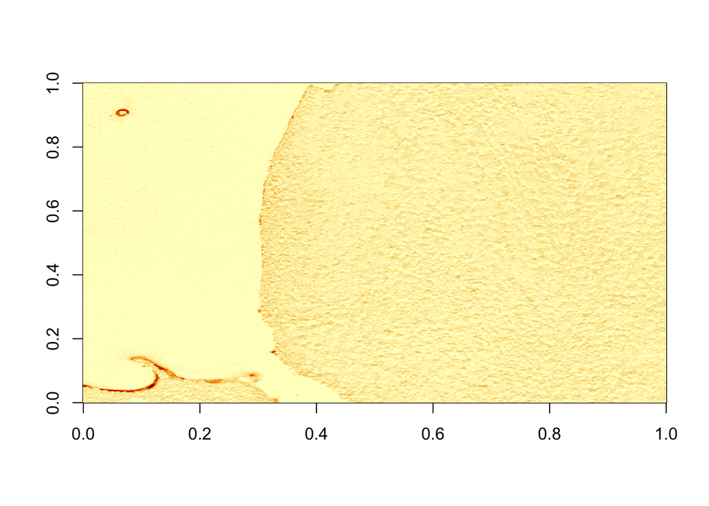

```r
image(b34)
```

The previous image is hard to visually interpret, let’s log the data and see what happens.

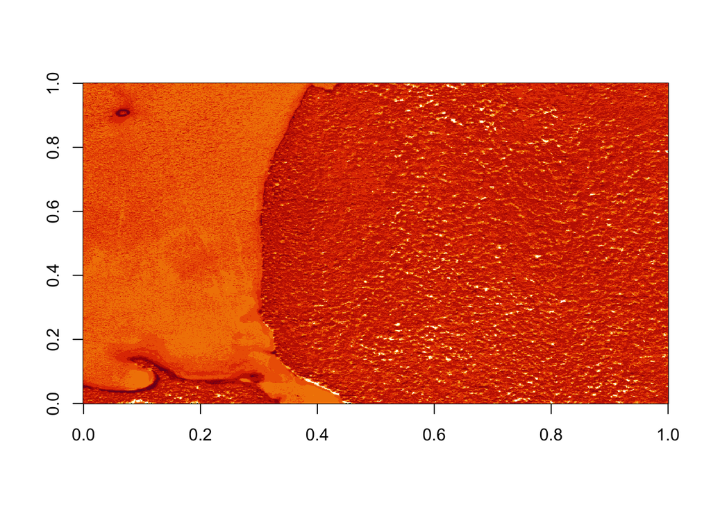

```r
image(log(b34))
```

### 3.0.7 Data cleaning

An image data in raster format will often contain a **data ignore** value and a **scale factor**. The data ignore value represents pixels where there are no data. Usually, no data values may be attributed to the sensor not collecting data in the area of the image or to processing results which yield null values.

From the reflectance metadata we can define the ignore value as **-9999**. Thus, let’s set all pixels with a value == -9999 to NA (no value).

```r
# there is NO data value in our raster - let's define it
myNoDataValue <- as.numeric(reflInfo$Data_Ignore_Value)

myNoDataValue
```

```
[1] -9999
```

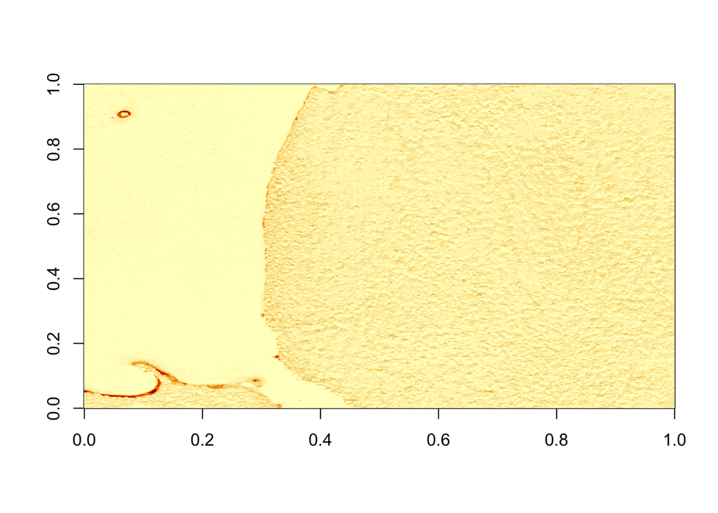

```r
# set all values equal to -9999 to NA
b34[b34 == myNoDataValue] <- NA

# plot the image now
image(b34)
```

# 4 Creating a georeferenced raster

In order to get a raster file suitable for further analysis, we first need to define the Coordinate reference system (CRS) of the raster. Again, we obtain the necessary information form the **HDF5** file.

```r
# Extract the EPSG from the h5 dataset
myEPSG <- h5read(fl, "/HARV/Reflectance/Metadata/Coordinate_System/EPSG Code")

myEPSG
```

```
[1] "32618"
```

```r
# convert the EPSG code to a CRS string
myCRS <- crs(paste0("+init=epsg:", myEPSG))

myCRS
```

```
[1] "PROJCRS[\"WGS 84 / UTM zone 18N\",\n    BASEGEOGCRS[\"WGS 84\",\n        ENSEMBLE[\"World Geodetic System 1984 ensemble\",\n            MEMBER[\"World Geodetic System 1984 (Transit)\"],\n            MEMBER[\"World Geodetic System 1984 (G730)\"],\n            MEMBER[\"World Geodetic System 1984 …
```

Define final raster with projection info.

```r
b34ras <- rast(b34, crs = myCRS)

# view the raster attributes
b34ras
```

```
class       : SpatRaster
size        : 1000, 1000, 1  (nrow, ncol, nlyr)
resolution  : 1, 1  (x, y)
extent      : 0, 1000, 0, 1000  (xmin, xmax, ymin, ymax)
coord. ref. : WGS 84 / UTM zone 18N
source(s)   : memory
name        : lyr.1
min value   :     0
max value   :  2839
```

Let’s take a look at the georeferenced raster. Take note of the coordinates on the x and y axis.

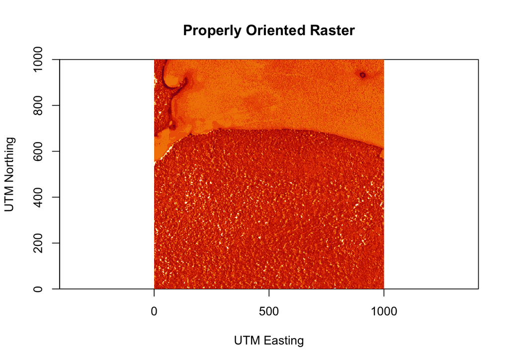

```r
image(log(b34ras),
      xlab = "UTM Easting",
      ylab = "UTM Northing",
      main = "Properly Oriented Raster")
```

Next we define the extents of our raster. The extents will be used to calculate the raster’s resolution. We get this information from the reflectance information obtained in a previous step.

```r
# Grab the UTM coordinates of the spatial extent
xMin <- reflInfo$Spatial_Extent_meters[1]
xMax <- reflInfo$Spatial_Extent_meters[2]
yMin <- reflInfo$Spatial_Extent_meters[3]
yMax <- reflInfo$Spatial_Extent_meters[4]
```

Define the spatial extent of the raster image

```r
# define the extent (left, right, top, bottom)
rasExt <- ext(xMin, xMax, yMin, yMax)

# view the extent to make sure that it looks right
rasExt
```

```
SpatExtent : 725000, 726000, 4700000, 4701000 (xmin, xmax, ymin, ymax)
```

Assign the spatial extent to the raster

```r
ext(b34ras) <- rasExt

# look at raster attributes
b34ras
```

```
class       : SpatRaster
size        : 1000, 1000, 1  (nrow, ncol, nlyr)
resolution  : 1, 1  (x, y)
extent      : 725000, 726000, 4700000, 4701000  (xmin, xmax, ymin, ymax)
coord. ref. : WGS 84 / UTM zone 18N
source(s)   : memory
name        : lyr.1
min value   :     0
max value   :  2839
```

Visualize the raster file but now let’s change the colors by adjusting the zlims.

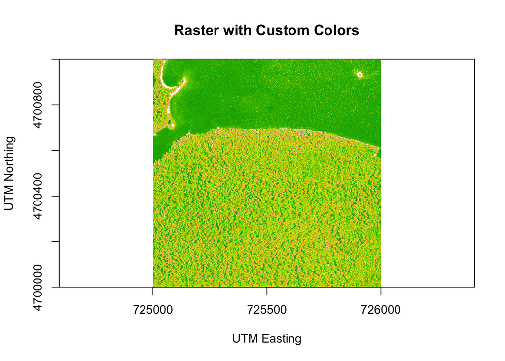

```r
col <- terrain.colors(25)

image(b34ras,
      xlab = "UTM Easting",
      ylab = "UTM Northing",
      main = "Raster with Custom Colors",
      col = col,
      zlim = c(0, 1000))
```

We can now save the created raster.

```r
# Create a new folder to store the results
dir.create("output")
# write out the raster as a geotiff
writeRaster(b34ras,
            file = "output/HARV_plot_001_band_34.tif",
            overwrite = TRUE)
```

## 4.1 Creating a RGB raster

In the previous step we created a raster file of a single band, but each hyperspectral data from the NEON-AOP contains 426 bands. In this step we will construct a raster stack file, i.e., a raster with N bands, in other words, a **raster of rasters**. You can do it manually as we did for the band 34, but let’s take advantage of **R** and write a function that do the work for us. Please, take your time to read and understand the function.

```r
# file: the hdf file
# band: the band you want to process
# noDataValue: values to be omitted
# extent: raster extent
# CRS: coordinates system
# returns: a matrix containing the reflectance data for the specific band

band2Raster <- function(file, band, noDataValue, extent, CRS){
    # first, read in the raster
    out <- h5read(file, "/HARV/Reflectance/Reflectance_Data",
                  index = list(band, NULL, NULL)) # path to the HDF5 file

    # Convert from array to matrix
    out <- (out[1,, ]) # output
    # transpose data to fix flipped row and column order
    # depending upon how your data are formatted you might not have to perform this
    # step.
    out <- t(out)
    # assign data ignore values to NA
    # note, you might chose to assign values of 15000 to NA
    out[out == myNoDataValue] <- NA

    # turn the out object into a raster
    outr <- rast(out, crs = CRS)

    # assign the extents to the raster
    ext(outr) <- extent

    # return the raster object
    return(outr)

}
```

Now apply the function to create a RGB raster file, to do this, we will use the bands 58, 34 and 19, respectively.

```r
# create a list of the bands we want in our stack
rgb <- list(58, 34, 19)

# lapply tells R to apply the function to each element in the list
rgb_harv <- lapply(rgb, # band numbers
                   FUN = band2Raster, # function
                   file = fl, # file from where data is extracted
                   noDataValue = myNoDataValue, # No data
                   extent = rasExt, # extent
                   CRS = myCRS) # Coordinate system

# check out the properties or rgb_rast
# note that it displays properties of 3 rasters.
rgb_harv
```

```
[[1]]
class       : SpatRaster
size        : 1000, 1000, 1  (nrow, ncol, nlyr)
resolution  : 1, 1  (x, y)
extent      : 725000, 726000, 4700000, 4701000  (xmin, xmax, ymin, ymax)
coord. ref. : WGS 84 / UTM zone 18N
source(s)   : memory
name        : lyr.1
min value   :     0
max value   :  3381

[[2]]
class       : SpatRaster
size        : 1000, 1000, 1  (nrow, ncol, nlyr)
resolution  : 1, 1  (x, y)
extent      : 725000, 726000, 4700000, 4701000  (xmin, xmax, ymin, ymax)
coord. ref. : WGS 84 / UTM zone 18N
source(s)   : memory
name        : lyr.1
min value   :     0
max value   :  2839

[[3]]
class       : SpatRaster
size        : 1000, 1000, 1  (nrow, ncol, nlyr)
resolution  : 1, 1  (x, y)
extent      : 725000, 726000, 4700000, 4701000  (xmin, xmax, ymin, ymax)
coord. ref. : WGS 84 / UTM zone 18N
source(s)   : memory
name        : lyr.1
min value   :     0
max value   :  2097
```

```r
# Create a raster stack from our list of rasters
rgb_harv_stack <- rast(rgb_harv)

rgb_harv_stack
```

```
class       : SpatRaster
size        : 1000, 1000, 3  (nrow, ncol, nlyr)
resolution  : 1, 1  (x, y)
extent      : 725000, 726000, 4700000, 4701000  (xmin, xmax, ymin, ymax)
coord. ref. : WGS 84 / UTM zone 18N
source(s)   : memory
names       : lyr.1, lyr.1, lyr.1
min values  :     0,     0,     0
max values  :  3381,  2839,  2097
```

As a final step, let’s assign the names of the bands to the raster stack object.

```r
# Create a list of band names
bandNames <- paste("Band_", unlist(rgb), sep = "")

# set the rasterStack's names equal to the list of bandNames created above
names(rgb_harv_stack) <- bandNames

# check properties of the raster list - note the band names
rgb_harv_stack
```

```
class       : SpatRaster
size        : 1000, 1000, 3  (nrow, ncol, nlyr)
resolution  : 1, 1  (x, y)
extent      : 725000, 726000, 4700000, 4701000  (xmin, xmax, ymin, ymax)
coord. ref. : WGS 84 / UTM zone 18N
source(s)   : memory
names       : Band_58, Band_34, Band_19
min values  :       0,       0,       0
max values  :    3381,    2839,    2097
```

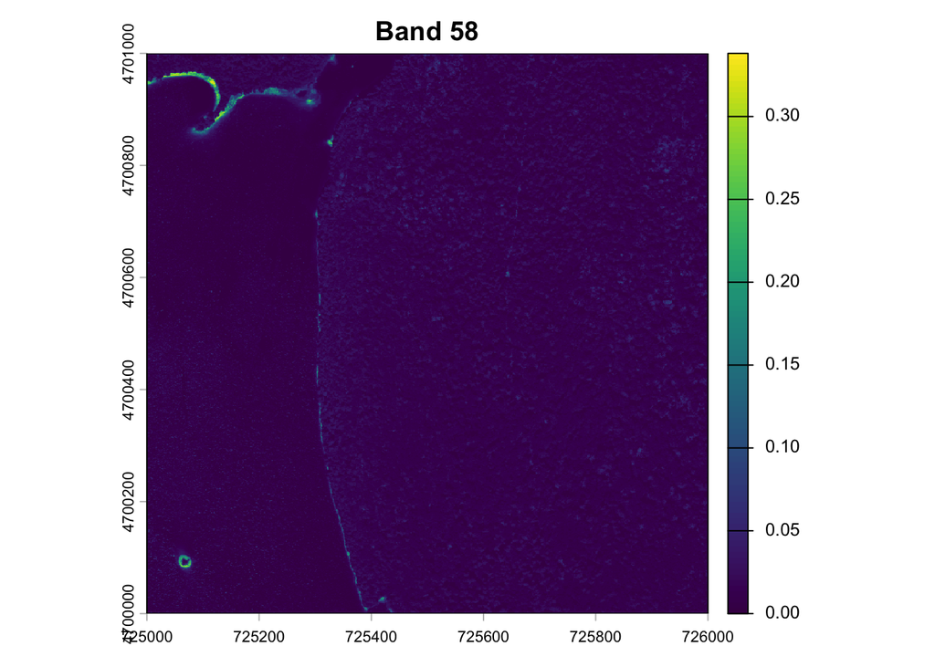

```r
# scale the data as specified in the reflInfo$Scale Factor
rgb_harv_stack <- rgb_harv_stack/as.integer(reflInfo$Scale_Factor)

# plot one raster in the stack to make sure things look OK.
plot(rgb_harv_stack$Band_58, main = "Band 58")
```

And plot resulting RGB raster.

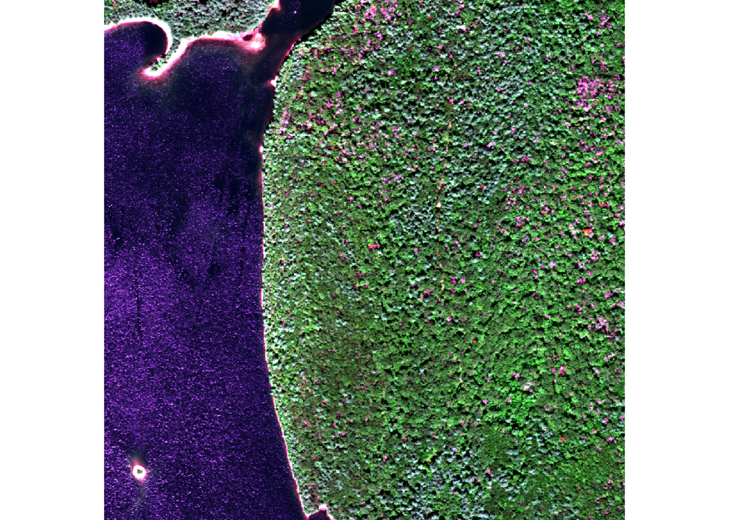

```r
# create a 3 band RGB image
plotRGB(rgb_harv_stack, # rasterstack
        r = 1, # red band
        g = 2, # green band
        b = 3, # blue band
        stretch = "lin")
```

Cool, right?

As we did with the band 34, let’s save the RGB raster in a GeoTIFF format.

```r
# write out final raster
writeRaster(rgb_harv_stack,
            file = "output/HARV_plot_001_RGB.tif",
            overwrite = TRUE)
```

## 4.2 Vegetation indices calculation

Now, we will calculate vegetation indices, specifically, we will calculate the Normalized Difference Vegetation Index (NDVI).

The **$NDVI$** is computed as the difference between near-infrared ($NIR$) and red ($RED$) reflectance divided by their sum.:

$$NDVI = \frac{NIR - R}{NIR + R}$$

To calculate the **NDVI** from the NEON-AOP hyperspectral data, first select the bands 58 (red) and 90 (NIR) and then create a raster stack as we did for the RGB raster.

### 4.2.1 Calculate NDVI

```r
# select bands to use in calculation (red, NIR)
ndvi_bands <- c(58, 90) #bands c(58, 90) in full NEON hyperspectral dataset

# create raster list and then a stack using those two bands
ndvi_harv <- lapply(ndvi_bands,
                    FUN = band2Raster,
                    file = fl,
                    noDataValue = myNoDataValue,
                    extent = rasExt,
                    CRS = myCRS)

ndvi_harv <- rast(ndvi_harv)

# make the names pretty
bandNDVINames <- paste("Band_", unlist(ndvi_bands), sep = "")
names(ndvi_harv) <- bandNDVINames

# view the properties of the new raster stack
ndvi_harv
```

```
class       : SpatRaster
size        : 1000, 1000, 2  (nrow, ncol, nlyr)
resolution  : 1, 1  (x, y)
extent      : 725000, 726000, 4700000, 4701000  (xmin, xmax, ymin, ymax)
coord. ref. : WGS 84 / UTM zone 18N
source(s)   : memory
names       : Band_58, Band_90
min values  :       0,       0
max values  :    3381,    8444
```

Write a function for **NDVI** calculation.

```r
#calculate NDVI
NDVI_func <- function(ras) {
      (ras[, 2] - ras[, 1])/(ras[, 2] + ras[, 1])
}
```

Apply the function and plot the result.

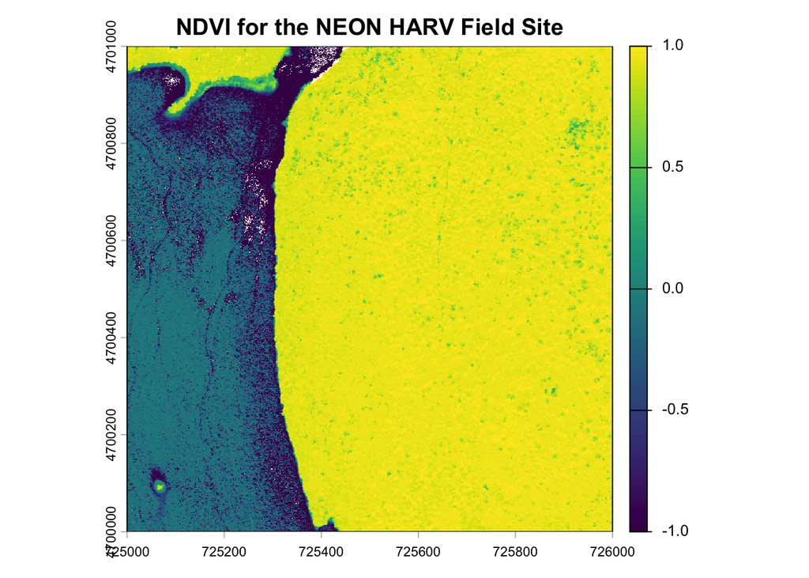

```r
ndvi_calc <- app(ndvi_harv,
                 fun = NDVI_func)

plot(ndvi_calc,
     main = "NDVI for the NEON HARV Field Site")
```

Now, play with breaks and colors to create a meaningful map add a color map with 4 colors.

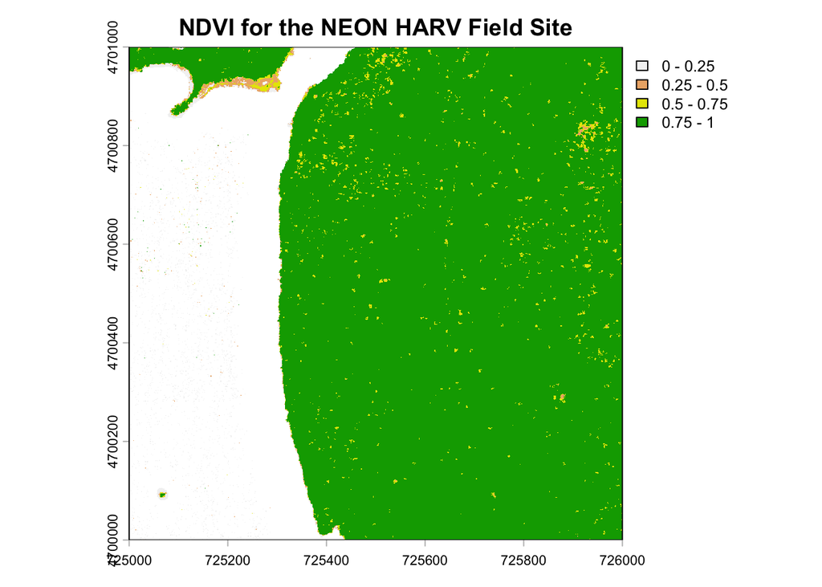

```r
myCol <- rev(terrain.colors(4)) # use the 'rev()' function to put green as the highest NDVI value
# add breaks to the colormap, including lowest and highest values (4 breaks = 3 segments)
brk <- c(0, .25, .5, .75, 1)

# plot the image using breaks
plot(ndvi_calc,
     main = "NDVI for the NEON HARV Field Site",
     col = myCol,
     breaks = brk)
```

We can save the resulting NDVI raster.

```r
writeRaster(ndvi_calc,
            file = "output/HARV_plot_001_NDVI.tif",
            overwrite = TRUE)
```

# 5 Plot spectral signatures derived from hyperspectral remote sensing data

Now we will extract all reflectance values for a selected pixel in the hyperspectral data from HARV and use this values to plot its spectral signatures. For practice purpose we will select a pixel at the position (100, 35), in other words, we are selecting the pixel at the row 100 and column 35. In addition to get the the reflectance for all bands we need to inform an empty space (as NULL).

```r
# extract all bands from a single pixel
aPixel <- h5read(fl, "/HARV/Reflectance/Reflectance_Data",
                 index = list(NULL, 100, 35))

class(aPixel)
```

```
[1] "array"
```

```r
# The line above generates a vector of reflectance values.
# Next, we reshape the data and turn them into a dataframe
b <- adply(aPixel, c(1))

class(b)
```

```
[1] "data.frame"
```

```r
# create clean data frame
aPixeldf <- b[2]

# add wavelength data to matrix
aPixeldf$Wavelength <- WL

head(aPixeldf)
```

```
   V1 Wavelength
1 328   383.7655
2 279   388.7733
3 257   393.7812
4 234   398.7890
5 227   403.7968
6 244   408.8047
```

Now select the scale factor from the reflectance object and scale the reflectance values for all bands.

```r
scaleFact <- reflInfo$Scale_Factor

# add scaled data column to the data frame
aPixeldf$scaled <- (aPixeldf$V1/as.vector(scaleFact))

# make nice column names
names(aPixeldf) <- c('Reflectance', 'Wavelength', 'ScaledReflectance')

head(aPixeldf)
```

```
  Reflectance Wavelength ScaledReflectance
1         328   383.7655            0.0328
2         279   388.7733            0.0279
3         257   393.7812            0.0257
4         234   398.7890            0.0234
5         227   403.7968            0.0227
6         244   408.8047            0.0244
```

```r
tail(aPixeldf)
```

```
    Reflectance Wavelength ScaledReflectance
421           0   2487.058            0.0000
422           0   2492.066            0.0000
423           0   2497.073            0.0000
424           0   2502.081            0.0000
425           0   2507.089            0.0000
426        1043   2512.097            0.1043
```

As a last step let’s plot the scaled reflectance as a function of the wavelength.

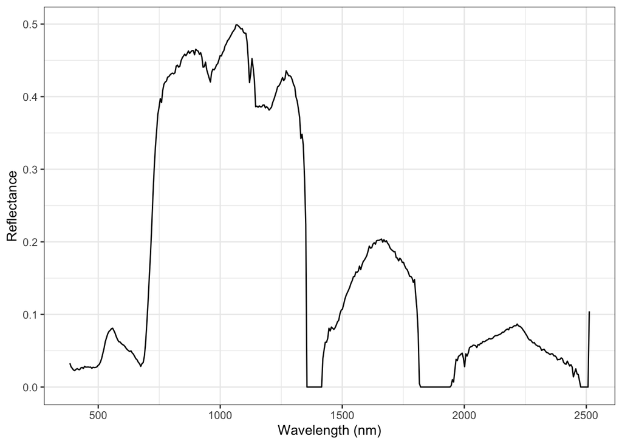

```r
aPixeldf %>%
  ggplot(aes(x = Wavelength, y = ScaledReflectance)) +
  geom_line() +
  xlab("Wavelength (nm)") +
  ylab("Reflectance") +
  theme_bw()
```

## 5.1 Select pixels and compare spectral signatures

In the previous step we selected and arbitrary pixel at (100, 35), however when we are working with real data we might need to have the spatial position of objects on the ground (e.g., GPS points).

We will use the exact geographical position of tree species in the HARV site. To do that, we will need to install two more packages that are not in **CRAN** but on **GitHub**. The packages are **geoNEON** and **neonhs**

First install and call the package **geoNEON**

```r
# install the package {geoNEON}
#remotes::install_github('NEONScience/NEON-geolocation/geoNEON', dependencies = TRUE)

if ( ! ("geoNEON" %in% installed.packages())) {
  remotes::install_github('NEONScience/NEON-geolocation/geoNEON',
                           dependencies = TRUE)
  }


library(geoNEON)
```

Now download the data from woody plant vegetation from NEON.

```r
# Download Woody plant vegetation structure from NEON #####
zipsByProduct(
  dpID = "DP1.10098.001",
  site = "HARV",
  savepath = "data/NEON",
  check.size = FALSE
)
```

```
Finding available files
```

```
Provisional data were excluded from available files list. To download provisional data, use input parameter include.provisional=TRUE.
```

```
Downloading files totaling approximately 128.439075 MB
```

```
data/NEON/filesToStack10098 already exists. Download will proceed, but check for duplicate files.
```

```
Downloading 46 files
```

```
46 files successfully downloaded to data/NEON/filesToStack10098
```

```r
## Combine the files
stackByTable("data/NEON/filesToStack10098", folder = TRUE)
```

```
Unpacking zip files using 1 cores.
```

[output not shown]

[output not shown]

[output not shown]

[output not shown]

[output not shown]

[output not shown]

[output not shown]

[output not shown]

[output not shown]

[output not shown]

[output not shown]

[output not shown]

[output not shown]

[output not shown]

[output not shown]

[output not shown]

[output not shown]

[output not shown]

[output not shown]

[output not shown]

[output not shown]

[output not shown]

[output not shown]

[output not shown]

[output not shown]

[output not shown]

[output not shown]

[output not shown]

[output not shown]

[output not shown]

[output not shown]

[output not shown]

[output not shown]

[output not shown]

[output not shown]

[output not shown]

[output not shown]

[output not shown]

[output not shown]

[output not shown]

[output not shown]

[output not shown]

[output not shown]

[output not shown]

[output not shown]

[output not shown]

```
Stacking data files
```

```
Finished: Stacked 6 data tables and 5 metadata tables!
```

```
Stacking took 1.495787 secs
```

```
All unzipped monthly data folders have been removed.
```

### 5.1.1 Prepare vegetation data

The function “getLocTOS” will refine the geolocation data associated with NEON data products.

```r
# Calculate the more precise location for each NEON plot in the HARV site
vegmap <- "data/NEON/filesToStack10098/stackedFiles/vst_mappingandtagging.csv" %>%
  read_csv() %>%
  mutate(year = substr(date, 1, 4)) %>%
  filter(year == '2019') %>%
  getLocTOS("vst_mappingandtagging") # Calculate more precise geolocations for specific NEON data products
```

```
Please note locations will be calculated only for mapped woody individuals. To find subplot locations for unmapped individuals, use this function with the vst_apparentindividual, vst_non-woody, and/or vst_shrubgroup tables.
```

```r
# Load individual tree coordinates
vegind <- read_csv("data/NEON/filesToStack10098/stackedFiles/vst_apparentindividual.csv")
# Combine the coordinates with three identification
vegetation <- right_join(vegind, vegmap,
  by = c("individualID", "namedLocation", "domainID", "siteID", "plotID")) %>%
  filter(!is.na(adjEasting), !is.na(adjNorthing),
         plantStatus == "Live")
```

Now select the individual trees available for the plot **HARV_001** and transform it into a spatial object.

```r
harv_01_trees <- vegetation %>%
  select(adjNorthing, adjEasting, scientificName, plotID,
         adjDecimalLatitude, adjDecimalLongitude) %>%
  filter(plotID == "HARV_001")
```

SF format

```r
# SF format
harv_01_trees_sf <- st_as_sf(harv_01_trees,
                       coords = c("adjEasting", "adjNorthing"),
                       crs = crs(ndvi_calc))
```

SP format

```r
# SPT format
harv_01_trees_spt <- harv_01_trees

coordinates(harv_01_trees_spt) <- ~ adjEasting + adjNorthing
crs(harv_01_trees_spt) <- crs(ndvi_calc)
```

```r
unique(harv_01_trees$scientificName)

length(harv_01_trees$scientificName)
```

Plot the results

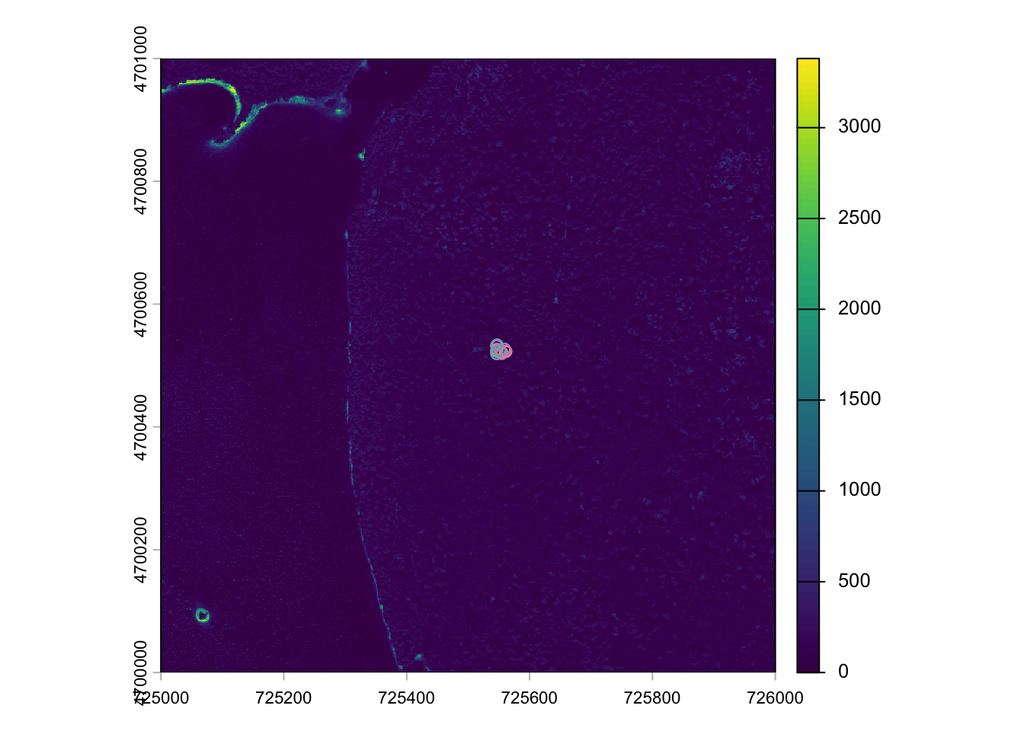

```r
plot(ndvi_harv[[1]])
plot(harv_01_trees_sf, add = TRUE)
```

This is not over, now we will extract the spectral information for each of our trees in the plot HARV_001. For this we will use the R package {neonhs}

### 5.1.2 Extract spectral data

First install and call the package **neonhs**

```r
#remotes::install_github('earthlab/neonhs')

if ( ! ("neonhs" %in% installed.packages())) {
  remotes::install_github('earthlab/neonhs')
  }

library(neonhs)
```

Extract the spectra data associated with each tree species.

```r
# Path to access the hyperspectral data
hs_path_2019 <- list.files(
  path = "data/NEON/DP3.30006.001/neon-aop-products/2019/",
  pattern = "reflectance.h5",
  recursive = TRUE, full.names = TRUE
)

# extract the spectra data
resHARV_001 <- neonhs::hs_extract_pts(filename = hs_path_2019, # path to the h5 file
                                      pts = harv_01_trees_spt, # spatial points
                                      bands = 1:426) # which bands
resHARV_001
```

```
class       : SpatialPointsDataFrame
features    : 53
extent      : 725546.2, 725561.7, 4700519, 4700534  (xmin, xmax, ymin, ymax)
crs         : +proj=utm +zone=18 +datum=WGS84 +units=m +no_defs
variables   : 432
names       :   scientificName,   plotID, adjDecimalLatitude, adjDecimalLongitude, band1_384nm, band2_389nm, band3_394nm, band4_399nm, band5_404nm, band6_409nm, band7_414nm, band8_419nm, band9_424nm, band10_429nm, band11_434nm, ...
min values  :   Acer rubrum L., HARV_001,   42.4242049282616,   -72.2584001428777,           0,           0,       6e-04,      0.0048,      0.0059,      0.0044,       0.006,      0.0054,      0.0041,       0.0062,       0.0058, ...
max values  : Quercus rubra L., HARV_001,   42.4243388123685,   -72.2582130792827,      0.0272,      0.0248,      0.0245,       0.023,      0.0235,      0.0257,      0.0215,      0.0233,      0.0225,       0.0247,       0.0266, ...
```

The object with the spectral data is a **SpatialPointsDataFrame** we need to transform it into a data.frame to continue working with the spectra.

```r
resHARV_001_df <- as.data.frame(resHARV_001) %>%
  bind_rows() %>%
  tibble() %>%
  dplyr::select(!c("band418_2472nm", "band419_2477nm", "band420_2482nm", "band421_2487nm",
            "band422_2492nm", "band423_2497nm", "band424_2502nm", "band425_2507nm",
            "band426_2512nm", "adjEasting.1", "adjNorthing.1")) %>%
  dplyr::select(plotID, scientificName, adjNorthing, adjEasting, adjDecimalLongitude, adjDecimalLatitude, everything())

resHARV_001_df
```

```
# A tibble: 53 × 423
   plotID   scientificName   adjNorthing adjEasting adjDecimalLongitude
   <chr>    <chr>                  <dbl>      <dbl>               <dbl>
 1 HARV_001 Pinus strobus L.    4700534.    725547.               -72.3
 2 HARV_001 Quercus rubra L.    4700526.    725547.               -72.3
 3 HARV_001 Acer rubrum L.      4700519.    725555.               -72.3
 4 HARV_001 Quercus rubra L.    4700523.    725562.               -72.3
 5 HARV_001 Pinus strobus L.    4700532.    725546.               -72.3
 6 HARV_001 Pinus strobus L.    4700525.    725551.               -72.3
 7 HARV_001 Quercus rubra L.    4700533.    725547.               -72.3
 8 HARV_001 Pinus strobus L.    4700527.    725559.               -72.3
 9 HARV_001 Quercus rubra L.    4700521.    725555.               -72.3
10 HARV_001 Acer rubrum L.      4700521.    725555.               -72.3
# ℹ 43 more rows
# ℹ 418 more variables: adjDecimalLatitude <dbl>, band1_384nm <dbl>,
#   band2_389nm <dbl>, band3_394nm <dbl>, band4_399nm <dbl>, band5_404nm <dbl>,
#   band6_409nm <dbl>, band7_414nm <dbl>, band8_419nm <dbl>, band9_424nm <dbl>,
#   band10_429nm <dbl>, band11_434nm <dbl>, band12_439nm <dbl>,
#   band13_444nm <dbl>, band14_449nm <dbl>, band15_454nm <dbl>,
#   band16_459nm <dbl>, band17_464nm <dbl>, band18_469nm <dbl>, …
```

Let’s perform a bit of cleaning…

```r
resHARV_001_df_long <- resHARV_001_df %>%
  dplyr::select(!c(plotID, adjNorthing, adjEasting, adjDecimalLongitude, adjDecimalLatitude)) %>%
  reshape2::melt(id.vars = "scientificName",
       variable.name = "Wavelength",
       value.name = "Reflectance")

resHARV_001_df_long <- resHARV_001_df_long %>%
  mutate(Wavelength2 = Wavelength) %>%
  separate(Wavelength2, into = c("bands", "wl"), sep = "_") %>%
  mutate(WL = as.numeric(gsub("[nm]", "", wl))) %>%
  mutate(scientificName = as.factor(scientificName))
```

Now let’s plot the results…

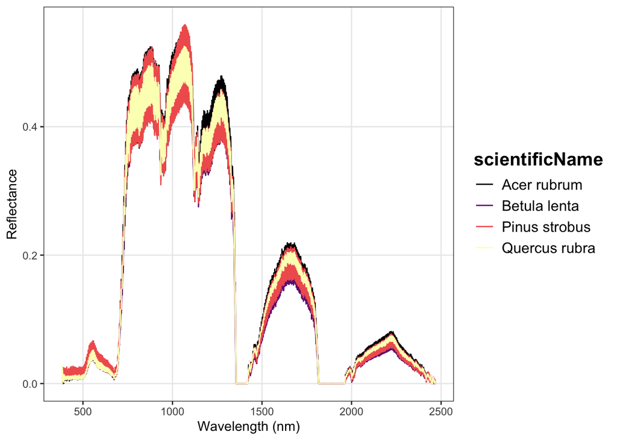

```r
# Aux function for visualization
theme_lab6 <- function() {
  theme_bw() +
    theme(panel.grid.minor = element_blank(),
          plot.background = element_rect(fill = "white", color = NA),

          strip.background = element_rect(fill = "grey80", color = NA),
          legend.title = element_text(face = "bold", size = 15),
          legend.text = element_text(size = 12))
}

# plot the spectra by species
resHARV_001_df_long %>%
  drop_na() %>%
  ggplot() +
  geom_line(aes(x = WL, y = Reflectance, color = scientificName)) +
  scale_color_viridis_d(option = "A",
                        labels = c("Acer rubrum",
                                   "Betula lenta",
                                   "Pinus strobus",
                                   "Quercus rubra")) +
  xlab("Wavelength (nm)") +
  ylab("Reflectance") +
  theme_lab6()
```

Cool! we just made a plot with the spectral signatures for four tree species at **HARV** site, but there are some anomalies in the plot which difficult its interpretation. Those anomalies around 1400 nm and 1850 nm correspond to **two major atmospheric absorption bands**, i.e., regions in the spectra where gasses in the atmosphere (primarily carbon dioxide and water vapor) absorb radiation, and therefore, obscure the reflected radiation that the imaging spectrometer measures.

To eliminate those anomalies we first might need to select and eliminate those bands manually. Happily, the reflectance metadata contains the lower and upper bound of each of those **atmospheric absorption bands**. Let’s read those bands and plot rectangles where the reflectance measurements are obscured by atmospheric absorbtion.

```r
# grab Reflectance metadata (which contains absorption band limits)
reflMetadata <- h5readAttributes(fl, "/HARV/Reflectance" )

ab1 <- reflMetadata$Band_Window_1_Nanometers
ab2 <- reflMetadata$Band_Window_2_Nanometers

ab1
```

```
[1] 1340 1445
```

```r
ab2
```

```
[1] 1790 1955
```

Plot spectral signatures again with rectangles showing the absorption bands

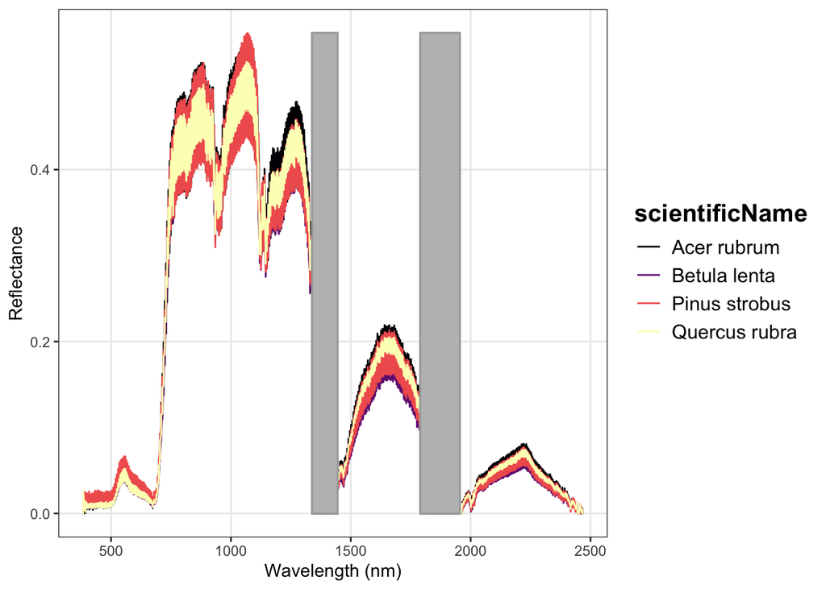

```r
resHARV_001_df_long %>%
  drop_na() %>%
  ggplot() +
  geom_line(aes(x = WL, y = Reflectance, color = scientificName)) +
  scale_color_viridis_d(option = "A",
                        labels = c("Acer rubrum",
                                   "Betula lenta",
                                   "Pinus strobus",
                                   "Quercus rubra")) +
  geom_rect(mapping = aes(ymin = min(Reflectance),
                          ymax = max(Reflectance),
                          xmin = ab1[1], xmax = ab1[2]),
            color = "darkgray", fill = "gray", alpha = 0.7) +
  geom_rect(mapping = aes(ymin = min(Reflectance),
                          ymax = max(Reflectance),
                          xmin = ab2[1], xmax = ab2[2]),
            color = "darkgray", fill = "gray", alpha = 0.7) +
  xlab("Wavelength (nm)") +
  ylab("Reflectance") +
  theme_lab6()
```

By inspecting the plot we can confirm that the sections of the spectra with anomalies are within the atmospheric absorption bands. Using the absorption band limits we can remove the sections with anomalies and plot masked spectral signatures for the four species.

```r
# Duplicate the spectral signatures into a new data.frame
resHARV_001_df_long_mask <- resHARV_001_df_long

# Mask out all values within each of the two atmospheric absorbtion bands
resHARV_001_df_long_mask[resHARV_001_df_long_mask$WL >
                    ab1[1] & resHARV_001_df_long_mask$WL < ab1[2], ]$Reflectance <- NA

resHARV_001_df_long_mask[resHARV_001_df_long_mask$WL >
                    ab2[1] & resHARV_001_df_long_mask$WL < ab2[2], ]$Reflectance <- NA

head(resHARV_001_df_long_mask)
```

```
    scientificName  Wavelength Reflectance bands    wl  WL
1 Pinus strobus L. band1_384nm      0.0093 band1 384nm 384
2 Quercus rubra L. band1_384nm      0.0000 band1 384nm 384
3   Acer rubrum L. band1_384nm      0.0009 band1 384nm 384
4 Quercus rubra L. band1_384nm      0.0272 band1 384nm 384
5 Pinus strobus L. band1_384nm      0.0082 band1 384nm 384
6 Pinus strobus L. band1_384nm      0.0069 band1 384nm 384
```

Plot the masked spectral signatures

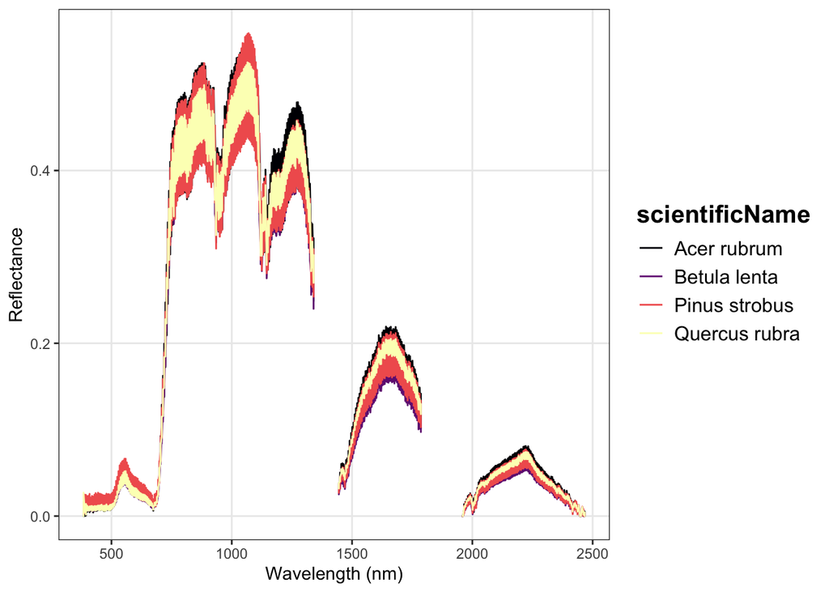

```r
resHARV_001_df_long_mask %>%
  ggplot() +
  geom_line(aes(x = WL, y = Reflectance, color = scientificName, group = scientificName)) +
  scale_color_viridis_d(option = "A",
                        labels = c("Acer rubrum",
                                   "Betula lenta",
                                   "Pinus strobus",
                                   "Quercus rubra")) +
  xlab("Wavelength (nm)") +
  ylab("Reflectance") +
  theme_lab6()
```

It’s always good practice to close the H5 connection before moving on.

```r
# close the H5 file
H5close()
```

Clean your R environment.

```r
rm(list = ls())
```

That’s it!

# 6 The challenge

This was a very long lab, and it will take some time to digest all the information. Thus, the challenge for this lab is simple. Prepare a document with all the figures generated in this tutorial and explain the figures related to the spectral profiles based on what you have learned in the lectures.